# Linear Regression: Fitting, Interpreting, Visualizing

Brad Price, Ph.D.

May 17, 2016

# Introduction to Regression

This section is called Linear Regression so to begin we need to define what regression is. Sandy Weisberg’s Applied Linear Regression Fourth Edition defines regression in the following way:

**Regression** *is the study of dependence*.

This may seem like a very general statement, but in fact regression can give us insight many questions. Some examples of these questions

- How does a female child’s height relate to her mothers height?
- Is the boiling point of water effected by the altitude?
- Does a change in treatment effect a disease? If so does it effect the disease after gender and other variables are accounted for?

More business oriented questions become:

- How does a new products success relate to it’s R&D lab?
- Is a products success effect by the marketing team or strategy?
- Does a change in marketing approach effect an individuals buying habit in a positive way?
- How does poverty relate to government compliance ratings of health insurance plans?

There are many others, and we will encounter some, but regression is just a general settting that can solve or give insight to many different problems.

In this course our main focus is on **linear regression**. This is the basic method that most advanced statistical methods methods rely on. This is also considered one of the basic methods in statistical analysis, and much more complex methods are built from this basic method. Something to keep in mind the rest of the program is that the term ``linear regression’’ does not refer to straight lines, but the combination of terms that create our regression model.

##The Data

The first thing you have to realize is that statistics is going through a fundamental change and has been for about 15 years. Questions can no longer be answered without a computer, the data is too large, questions answered with pen and paper tend to be theoretical or for homework exercises only. With this in mind no analysis can start without getting the data read into a statistical programming language, such as R (what we will use), SAS, SPSS,…etc.

Though computing is a big part of regression we need to define some notation that will hold for the rest of your statistics courses. Since we defined regression as the study of dependence in general so we need at least two variables to study. We will define the variable $Y$ as the response variable (dependent variable) and the predictor variable $X$ (independent variable). The idea is that we think $X$ and $Y$ have a relationship such that $Y$ depends on $X$ regression is how we try to quantify the relationship. In the real world we only observe samples of $X$ and $Y$. and we always observe them jointly or paired (from their joint distribution). Our sample will always be of size $n$ and we define the sample $(Y,X) =\{(y_1,x_1),(y_2,x_2),\dots,(y_n,x_n)\}$. From this point on when discussing data
$$Y=\left(\begin{array}{c}
y_1 \\
\vdots\\
y_n
\end{array}
\right)
\,\mathrm{and}\,
\, X=\left(\begin{array}{c}
x_1 \\
\vdots\\
x_n
\end{array}
\right)$$

For the moment we will restrict $X$ to be one dimensional (a single variable), but as the course progresses when will let $X$ be an $n \times p$ matrix. This will allow us a little more freedom once we understand the basics. In the beginnings of our discussions of regression we are going to assume $X$ and $Y$ both are continuous.

In the case described above, where we want to understand how a products sucesses relates to the R&D lab it was produced in we say that the dependent variable is the product success (however you want to define that), and the independent variable is the R&D lab. In the case of heights, we want to predict a daughters height (the response/ dependent variable) while knowning her mothers height (the predictor/ independent variable).

## Data Visualization

Now that we have a sample of size $n$ the first thing we need to do is understand the basics of our data. In regression this is more than just looking at the mean and standard deviation of each variable individually though 5 number summaries (mean, median, quartiles) and other summary statistics (standard deviations, variances) should always be used this doesn’t really tell us about the relationship between $X$ and $Y$, which is what we are most interested in. To depict this we need to use metrics that describe the relationship between $X$ and $Y$ such as correlation. But a major issue with correlation is it only describes linear relationships, and this is not the only relationship we care about. The most useful thing we can do to understand the relationship between $X$ and $Y$ is to plot the data we have using a scatterplot. If we have more than one predictor variable we will use what is known as a scatterplot matrix. A scatterplot matrix is exactly what it sound like, it is multiple scatterplots arrange in a matrix form, so we can depict relationships side by side. Below is a simple example in R that creates the figure below.

```r
library(alr4)
```

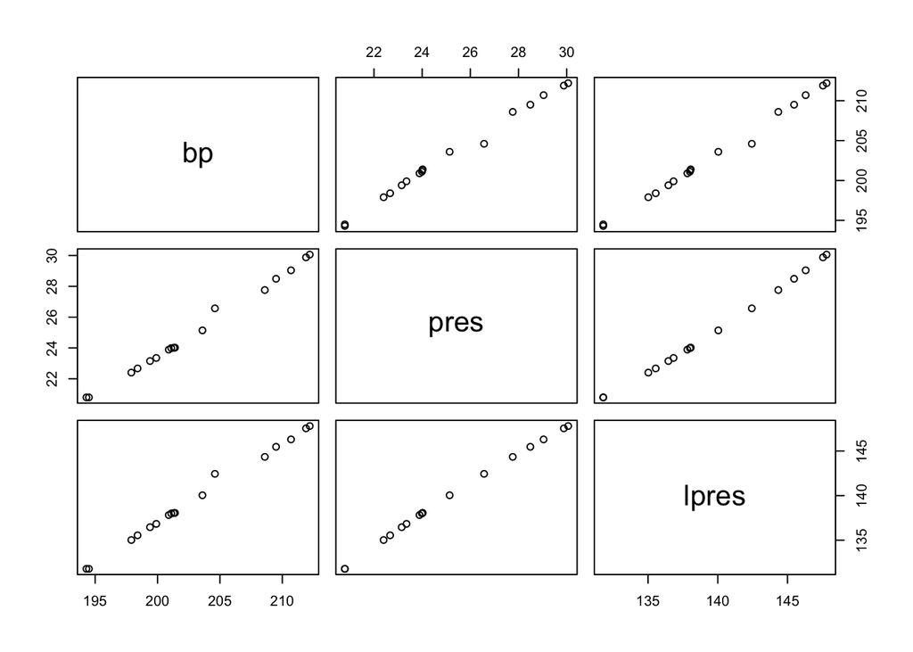

```r
plot(Forbes)
```

The data set is a very famous example of linear relationships that looks at how the boiling point of water is effected by altitude, measure by barometric pressure. In this case bp is the boiling point of water, press is the pressure, and lpress is the natural log of pressure. We’ll return to this data set later on in the course, as it has an interesting case study in it.

Notice a single element of the matrix is just a scatter plot, it shows the relationship, but a scatterplot matrix allows us to visualize the relationships between three variables at once. On the diagonal are the variable names, the variable corresponding to the row of the plot is on the vertical (Y) axis, while the variable corresponding to the row is the horizontal (X) axis.

So we can see from the plot that we can start to discuss how $X$ and $Y$ relate to one another, in statistics terms we are trying to understand the joint distribution of $X$ and $Y$. We need to be able to discuss extreme points we view in plots. Figure 2 gives a graphical definition of extreme values of both the response $Y$ and predictor $X$. We need to ``formally’’ define this as well:

- Define a **Leverage Point** as a point with extreme predictor values.
- Define an **Outlier** as a point with an extreme response value, realitive to it’s value of the predictor.

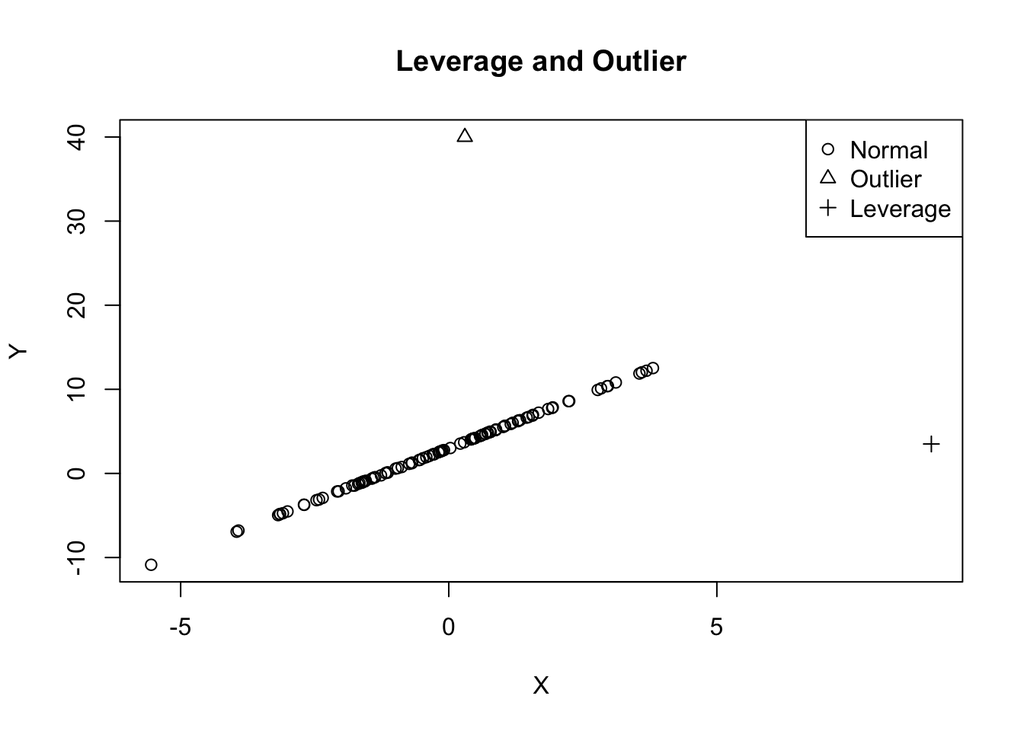

```r
set.seed(110)
X<-rnorm(100,0,2)
Y=3+2.5*X+rnorm(100,0,.03)
Y2=c(Y,40,3.5)
X2=c(X,.3,9)
type=c(rep(1,100),2,3)
plot(Y2~X2,xlab="X",ylab="Y",main="Leverage and Outlier",pch=type)
legend("topright", c("Normal","Outlier","Leverage"),pch=c(1,2,3))
```

The plots we’ve seen so far give us an example of when $X$ and $Y$ have a relationship, but some times the more important question is whether or not $Y$ and $X$ have any relationship at all. If there is no relationship and we try to define one we can waste a lot of time. Again this is the reason we plot the data first!!! The figure below is an example of what we call a ``null plot’’. A null plot is a plot that depicts $X$ and $Y$ being independent.

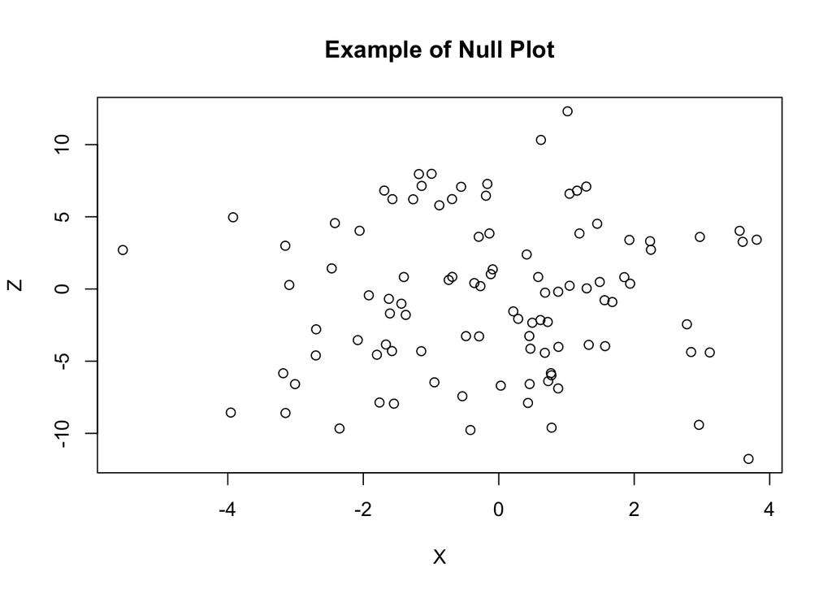

```r
Z=rnorm(100,0,5)
plot(Z~X,main='Example of Null Plot')
```

## Conditional Distributions

Graphically we have said that depicting the relationship between a predictor and response can be done using scatter plots. Simplistically this is true but in statistics scatter plots also give us insight to the joint distribution of $(Y,X)$. Remember from your intro class the joint distribution says something about how $(Y,X)$ relate to each other. This is great but normally we want to understand how $Y$ depends on $X$, so the joint distribution isn’t exactly what we want to find. Since we know $X$ is our predictor or our independent variable we will always know or set it. The overall idea is to understand the conditional distribution of $Y\mid X$. In our course we will specifically stick to discussing two parameters the conditional mean, $E(Y\mid X)$, and conditional variance, $Var(Y\mid X)$. Looking at the distribution of $Y \mid X$ over $Y$ complicates things a little but we are looking for two very specific things:

$$E(Y \mid X=x)=g(x)\\
Var(Y) > Var(Y\mid X=x)$$
Where $g$ is a function we have defined.

The main idea here is we want to not just understand the variable $Y$ but more importantly how $Y$ relates to $X$ and the information we can leverage about $Y$ if we know $X$. The whole idea is summed up in that second equation, can we use $X$ to reduce the variance in $Y$, in laymens terms can we get a better feel about the response given I know some outside information.

###Conditional Mean Notice a few things about these ``ideal’’ requirements. The first thing is that $Y$ actually has some relationship to $X$. If for every $x$
$$E(Y\mid X=x)=E(Y)$$
then our scatter plot is a null plot, thus knowing $X$ does not help us explain any of the information in $Y$. Therefore knowing $X$ isn’t really useful for understanding Y, and then any methods we come up with are pointless.

Let’s ignore this setting for now and say that $E(Y\mid X=x)=g(x)$. We expect that there is some random variation that we will never be able to explain in $Y$, another way to say this is we will never be able to predict perfectly. We also know it is easier to discuss what will happen on average than for a specific case. With this in mind in regression we use the mean for the predicted value (also referred to as the fitted value). An important term in regression and something we will use constantly throughout the class is the theoretical residual. Define for data point $(y_i,x_i)$
$$y_i=E(Y\mid X=x_i)+\epsilon_i=g(x_i)+\epsilon_i$$

We define $\epsilon_i$ to be the $i$th theoretical residual, the piece we will never be able to understand. This equation shouldn’t be a surprise, since $\epsilon_i$ is unique to each data point we can add any number to the mean that will result in $y_i$. So in essence the residual is:

Residual=Actual-Fitted=Actual-Mean

One way to think about this is that the fitted value you is our prediction, so the residual is the differance between the the actual and our prediction, so it’s a measure of how wrong our prediction is. If we think of it the second way it is just the difference between the data and the mean, which is just a measurement of distance from the data to the average.

We can see what estimation of the conditonal mean function does is give us a better predicted value based on $X$ than just using $E(Y)$.

###Conditional Variance

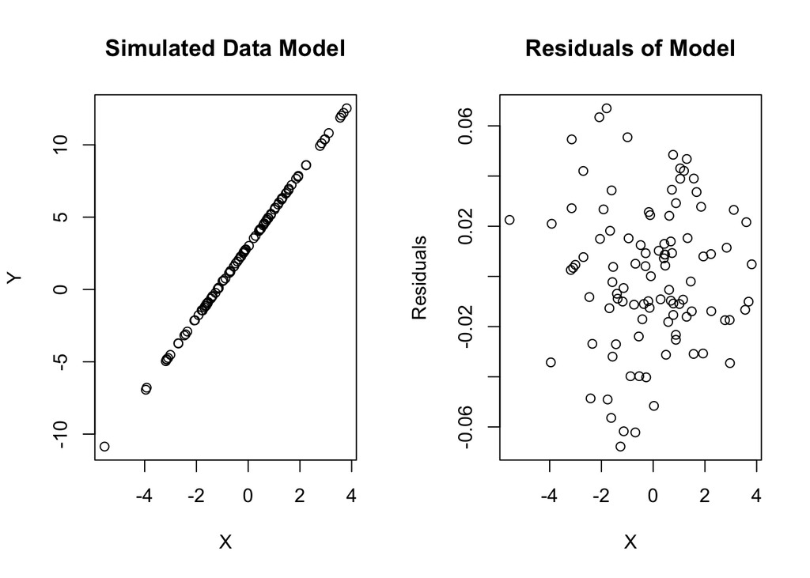

```r
par(mfrow=c(1,2))
plot(Y~X,main='Simulated Data Model')
model<-lm(Y~X)
plot(model$residuals~X,ylab='Residuals',main='Residuals of Model')
```

The second aspect we concern ourself with is the conditional variance function. One thing people discuss and can be thought of as a main point of regression is reduction of variance. In essence the question becomes given that we know $X$ how much more certain are we in the value of $Y$? If we have accounted for some variance in $Y$ that means the variance of $Y\mid X$ is smaller than the variance of $Y$. A common assumption we use is that for every $x$
$$Var(Y \mid X=x)=\sigma^2$$

The variance of the conditional distribution is also the variance of the residuals. Looking at the figure above we can compare the variance of $Y$ to the variance of the residuals. This makes sense to use because the conditional distribution at the point $x_i$, is the same as the residual for the point $y_i$. We will discuss this more in-depth as the courese goes on.

```r
var(model$residuals)
```

```
## [1] 0.0008243385
```

```r
var(Y)
```

```
## [1] 21.76765
```

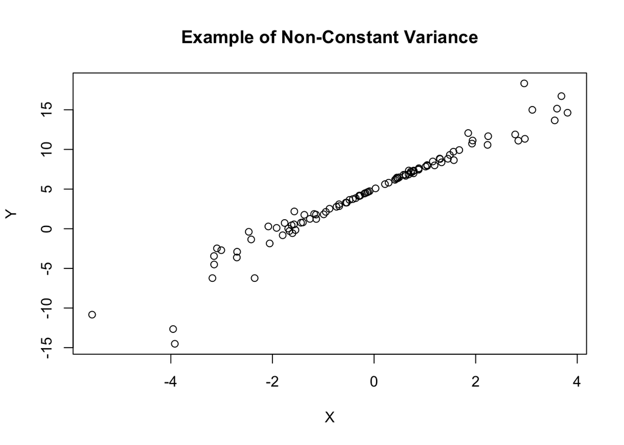

```r
Y4=rep(0,length(X))
for(i in 1:length(X)){
Y4[i]=5+3*X[i]+rnorm(1,0,.3*X[i]^2)
}
plot(Y4~X,ylab="Y",main="Example of Non-Constant Variance")
```

##Lowess/Loess Smoothers There are many different types of mean functions that can be used for regression:

- $E(Y \mid X=x)=\beta_0+\beta_1*x$ which is referred to as Simple Linear Regression
- Non-Parametric Functions
- $E(Y \mid X=x)=\beta_0+ \beta_1\{1-e^{-\beta_2x}\}$

The main focus for this section will be on non-parametric functions, specifically Lowess/Loess smoothers. Lowess stands for Locally WEighted Scatterplot Smoothers, and we can view this method as ``letting the data fit itself’’. Ideally smoothers in general use non-parametric methods to find a mean or prediction function for our data. The local allows us to use the closest points of our data to help with prediction at each point we are concerned with. The idea is that for every data point we have (we cannot generalize outside of the bounds of this data) we will predict the mean using the closest $m$ points. We define $f$ as a percentage of the data and then use this to calculate the mean function. We will get into more specifics of how this works later but for now let’s just see how we can fit a smoother to the data and see how it works.

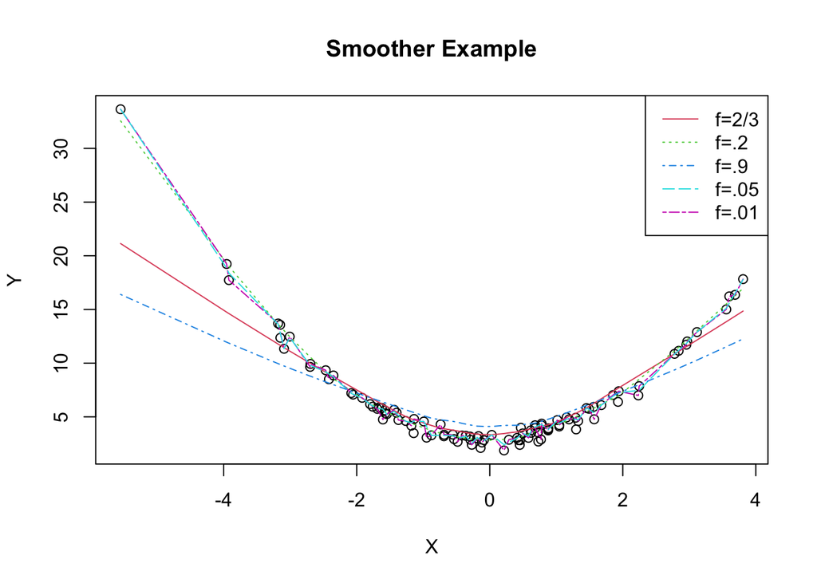

```r
Y3=3+X^2+rnorm(100,0,.5)
plot(Y3~X,ylab='Y',main='Smoother Example')
lines(lowess(X,Y3,f=2/3),col=2)
lines(lowess(X,Y3,f=.2),lty=3,col=3)
lines(lowess(X,Y3,f=.01),lty=6,col=6)
lines(lowess(X,Y3,f=.05),lty=5,col=5)
lines(lowess(X,Y3,f=.9),lty=4,col=4)
legend("topright",c("f=2/3","f=.2","f=.9","f=.05","f=.01"),lty=c(1,3,4,5,6),col=c(2,3,4,5,6))
```

Notice that the lower the $f$ value is the more local the smoother becomes. This means that the data could “oversmoothed”, which means we lose the idea of a general trend and start playing “connect the dots”. The idea of local regression is something we need to keep in mind moving forward, it is a way to tell if a model we create can generalize, or if our data functions differently across different parts of our predictors.

## Simple Linear Regression

**Simple linear regression** (SLR) defines a very specific regression models where:
$$E(Y\mid X=x)=\beta_0+\beta_1x\\
Var(Y \mid X=x)=\sigma^2$$

Where we define:

- $\beta_0$ as the intercept (Y-Intercept)
- $\beta_1$ as the slope of the line (Rise Over Run)
- $\sigma^2>0$ (Constant Variance)

The constant variance assumption is probably the most restrictive thing in this model, as it says that the variance around the line must be constant. We will spend a lot of time on this in latter sections of this course.

You’ve probably seen something like this in a previous course or even as far back as algrebra where you were asked to define a line that went through two points. Now we know that these two points come from a sample $(y_1,x_1),\dot,(y_n,x_n)$, so it is not as easy to calculate these values now. We will get to how to interpret these values and use our entire sample later on. For no let’s concern ourself with why this model is refered to as simple linear regression and some of the basic princples that can be incorporated.

The reason we refer to this model as SLR, is that ther terms are linear, made up simple multiplication and addition (or subtraction and division). An example of linear terms could be:
$$aY_1+bY_2+\ldots.$$
Don’t confuse this with “we can only have straight lines” that is not true! The term simple is used because we only have a single predictor variable, X. This means we only have one slope coefficent, which makes life “simple”.

Now in previous course you may have seen notation like $y=mx+b$ be the equation for a line, we are trying to model $E(Y\mid X=x)$, the average $Y$ and a given value of $X$. We know that our expected value will not always be our observed value, so again we define the theoretical residual for the $i$th data point in our sample as:
$$\epsilon_i=y_i-E(Y\mid X=x_i)$$
This is also refered to as statistical error. The easiest way to think of it is the vertical distance between your observed value and the mean function.

Remember that:
$$y_i=E(Y\mid X=x_i)+\epsilon_i$$

After we make assumptions on our mean function such as SLR and constant variance, we make assumption on our residuals or errors. The two assumptions we make are:
$$E(\epsilon \mid X=x_i)=0$$

What this means to us is that our mean function “detrended” our data. There is no more relevant information in the relationship between $X$ and $Y$.

- $\epsilon_i$’s are independent of one another

Knowing one error term shouldn’t be able to tell us anything about the others. You can think of this as stemming from the fact that all the $Y$’s are independent.

Other assumptions made is that $\epsilon$ follows a normal distribution. This is a very restrictive assumption, but we will use it for things such as tests and intervals later on in this section

## Ordinary Least Squares

Now that we have defined SLR, we need to know how to estimate our 3 parameters ($\beta_0$,$\beta_1$,$\sigma^2$) based on our sample. The traditional, and most common way to do this is to use what is known as the Ordinary Leasy Squares estimator (OLS). We will denote parameter estimates with $\hat{\beta_0}$, $\hat{\beta_1}$, $\hat{\sigma}^2$. Also let
$$\hat{y}_i=\hat{E}(Y\mid X=x_i)=\hat{\beta}_0+\hat{\beta}_1x_i$$
We will refer to $\hat{y}_i$ as the fitted value for the $i$th data point. We define the residual as:$y_i-\hat{y}_i$.

The idea of OLS is to minimize the Residual Sum of Squares (RSS). We define:
$$RSS(\beta_0,\beta_1)=\sum_{i=1}^n(y_i-(\beta_0+\beta_1x_i))^2$$
To find $(\hat{\beta}_0,\hat{\beta}_1)$ we minimize the RSS. For those interested in the theoretial side of regression, the RSS is based on the log-likelihood of the assumption that: $Y\mid X=x \sim N(\beta_0+\beta_1x, \sigma_2)$.

We will develop this in depth in later sections. For now we need to introduce some notation that will help us as we develop the formuals for the estimators.

| Notation | Equation | Description |
| --- | --- | --- |
| $\bar{x}$ | $\frac{\sum x_i}{n}$ | Sample average of $x$ |
| $\bar{y}$ | $\frac{\sum y_i}{n}$ | Sample average of $y$ |
| $SXX$ | $\sum (x_i-\bar{x})^2$ | Sum of Squares for $x$ |
| $\hat{Var}(x)$ | $\frac{SXX}{n-1}$ | Sample Variance of $x$ |
| $SYY$ | $\sum (y_i-\bar{y})^2$ | Sum of Squares of $y$ |
| $\hat{Var}(y)$ | $\frac{SYY}{n-1}$ | Sample Variance of $y$ |
| $SXY$ | $\sum (x_i-\bar{x})(y_i-\bar{y})$ | Sum of cross-product of $x$ and $y$ |
| $\hat{Cov}(x,y)$ | $\frac{SXY}{n-1}$ | Sample Covariance |
| $\hat{Cor}(x,y)$ | $\frac{\hat{Cov}(x,y)}{\sqrt{\hat{Var}(x)\hat{Var}(y)}}$ | Sample Correlation |

Note that when I write $\sum$ without any subscript it means to sum over all observations. Also notice the hat rule if there is a $hat{y}$ or a $\bar{y}$ over a variable it means it is estimated from our sample. If not it is the population or theoretical statistic.

### Derivation and Equations

Our goal is to find the pair $(\hat{\beta}_0,\hat{\beta}_1)$ that minimizes $RSS(\beta_0,\beta_1)$. To solve :
$$\arg_{(\beta_0,\beta_1)} \min \sum_{i=1}^n (y_i-\beta_0-\beta_1x_i)^2$$
We take the first derivative with respect to $\beta_0$ and set it equal to zero then we solve for $\hat{\beta}_0$.

$$\frac{\delta RSS(\beta_0,\beta_1)}{\delta\beta_0}= -2(\sum_{i=1}^n(y_i-\beta_0-\beta_1 x_i))\\
\Rightarrow \\
0=-\sum_{i=1}^ny_i +n\beta_0+\beta_1\sum_{i=1}^nx_i\\
\Rightarrow\\
n\beta_0 = \sum_{i=1}^ny_i-\beta_1\sum_{i=1}^nx_i\\
\Rightarrow\\
\hat{\beta}_0=\bar{y}-\beta_1\bar{x}\\$$

Now that we have our estimate for $\hat{\beta}_0$ we insert it into $RSS(\beta_0,\beta_1)$ and then solve first derivative set equal to 0 for $\beta_1$. So we have that:

$$\frac{\delta RSS(\hat{\beta}_0,\beta_1)}{\delta\beta_1}= -2\sum_{i=1}^n(x_i-\bar{x})((y_i-\bar{y})-\beta_1(x_i-\bar{x}))=0\\
\Rightarrow\\
0=SXY-\beta_1 SXX\\
\Rightarrow\\
\hat{\beta}_1=\frac{SXY}{SXX}$$

So what we now have is that:
$$\begin{eqnarray}
\hat{\beta}_1&=&\frac{SXY}{SXX}\\
\hat{\beta}_0&=&\bar{y}-\hat{\beta}_1\bar{x}
\end{eqnarray}$$

But what do these parameters actually mean? We can think of the OLS equation, the line produced from OLS, as the line that minimizes the variance of the residuals for a straight line. Again this line is the expected mean given the $X$ variable. Using a different function than $RSS(\beta_0,\beta_1)$ will produce a different equation with a completely different interpretation. Take a look at SXY, SXX, and SYY, these correspond to the numerator of covaraince, variance of the predictor, and variance of the response. So really we can estimate these parameters using means, varaince, and covariance. This is something to keep in mind for when we move into “big data” problems.

We have one last parameter to estimate $\sigma^2$. We calculate
$$\hat{\sigma}^2=\frac{RSS(\hat{\beta}_0,\hat{\beta}_1)}{n-2}$$
We also know that $\hat{\sigma}^2$ is the variance of the conditional distribution of $Y \mid X=x$ but also the residuals. Lastly we refer to $\hat{\sigma}$ as the standard error of regression, and is in the same units as the response. The $n-2$ is the degrees of freedom, note we estimate two coefficients $\beta_0$ and $\beta_1$, in general this will be $n-p-1$ where $p$ is the number of predictor variables. In this case $p=1$ since we only have one predictor variable.

### AIS Example

We will look at an example from the AIS data in the alr4 package. Though not it’s purpose we will look at the relationship between height and weight of Australian athletes. First we will load the data and take a look at the summary.

```r
library(alr4)
data(ais)
attach(ais)
summary(ais)
```

```
##       Sex              Ht              Wt              LBM
##  Min.   :0.000   Min.   :148.9   Min.   : 37.80   Min.   : 34.36
##  1st Qu.:0.000   1st Qu.:174.0   1st Qu.: 66.53   1st Qu.: 54.67
##  Median :0.000   Median :179.7   Median : 74.40   Median : 63.03
##  Mean   :0.495   Mean   :180.1   Mean   : 75.01   Mean   : 64.87
##  3rd Qu.:1.000   3rd Qu.:186.2   3rd Qu.: 84.12   3rd Qu.: 74.75
##  Max.   :1.000   Max.   :209.4   Max.   :123.20   Max.   :106.00
##
##       RCC             WCC               Hc              Hg
##  Min.   :3.800   Min.   : 3.300   Min.   :35.90   Min.   :11.60
##  1st Qu.:4.372   1st Qu.: 5.900   1st Qu.:40.60   1st Qu.:13.50
##  Median :4.755   Median : 6.850   Median :43.50   Median :14.70
##  Mean   :4.719   Mean   : 7.109   Mean   :43.09   Mean   :14.57
##  3rd Qu.:5.030   3rd Qu.: 8.275   3rd Qu.:45.58   3rd Qu.:15.57
##  Max.   :6.720   Max.   :14.300   Max.   :59.70   Max.   :19.20
##
##       Ferr             BMI             SSF              Bfat
##  Min.   :  8.00   Min.   :16.75   Min.   : 28.00   Min.   : 5.630
##  1st Qu.: 41.25   1st Qu.:21.08   1st Qu.: 43.85   1st Qu.: 8.545
##  Median : 65.50   Median :22.72   Median : 58.60   Median :11.650
##  Mean   : 76.88   Mean   :22.96   Mean   : 69.02   Mean   :13.507
##  3rd Qu.: 97.00   3rd Qu.:24.46   3rd Qu.: 90.35   3rd Qu.:18.080
##  Max.   :234.00   Max.   :34.42   Max.   :200.80   Max.   :35.520
##
##        Label        Sport
##  f-netball:23   row    :37
##  f-row    :22   t_400m :29
##  m-t_400m :18   b_ball :25
##  m-w_polo :17   netball:23
##  m-row    :15   swim   :22
##  f-b_ball :13   field  :19
##  (Other)  :94   (Other):47
```

Next we will calculate the slope and intercept using brute force, treating r as a calculator and not a statistical software.

```r
cor(Ht,Wt)
```

```
## [1] 0.7809063
```

```r
cov(Ht,Wt)
```

```
## [1] 105.8584
```

```r
(VarH=var(Ht))
```

```
## [1] 94.76038
```

```r
(VarW=var(Wt))
```

```
## [1] 193.9216
```

```r
(MH=mean(Ht))
```

```
## [1] 180.104
```

```r
(MW=mean(Wt))
```

```
## [1] 75.00817
```

```r
(n=length(Ht))
```

```
## [1] 202
```

```r
SXX=(n-1)*VarH
SYY=(n-1)*VarW
SXY=cov(Ht,Wt)*(n-1)
(Beta1=SXY/SXX)
```

```
## [1] 1.117117
```

```r
(Beta0=MW-Beta1*MH)
```

```
## [1] -126.189
```

Next le’ts use the lm function in R to show the same thing. Notice we will also see what we have access to from lm, and summary of an lm. This is extremely important to remember as you can get residuals and coefficients quickly, as well as fitted values.

```r
(mod=lm(Wt~Ht))
```

```
##
## Call:
## lm(formula = Wt ~ Ht)
##
## Coefficients:
## (Intercept)           Ht
##    -126.189        1.117
```

```r
names(mod)
```

```
##  [1] "coefficients"  "residuals"     "effects"       "rank"
##  [5] "fitted.values" "assign"        "qr"            "df.residual"
##  [9] "xlevels"       "call"          "terms"         "model"
```

```r
summary(mod)
```

```
##
## Call:
## lm(formula = Wt ~ Ht)
##
## Residuals:
##     Min      1Q  Median      3Q     Max
## -16.372  -5.296  -1.197   4.378  38.030
##
## Coefficients:
##               Estimate Std. Error t value Pr(>|t|)
## (Intercept) -126.18901   11.39656  -11.07   <2e-16 ***
## Ht             1.11712    0.06319   17.68   <2e-16 ***
## ---
## Signif. codes:  0 '***' 0.001 '**' 0.01 '*' 0.05 '.' 0.1 ' ' 1
##
## Residual standard error: 8.72 on 200 degrees of freedom
## Multiple R-squared:  0.6098, Adjusted R-squared:  0.6079
## F-statistic: 312.6 on 1 and 200 DF,  p-value: < 2.2e-16
```

```r
names(summary(mod))
```

```
##  [1] "call"          "terms"         "residuals"     "coefficients"
##  [5] "aliased"       "sigma"         "df"            "r.squared"
##  [9] "adj.r.squared" "fstatistic"    "cov.unscaled"
```

We can see that the calculations by had (using R) and the R function lm() match up perfectly. To place a line on the plot we can simply use the code below.

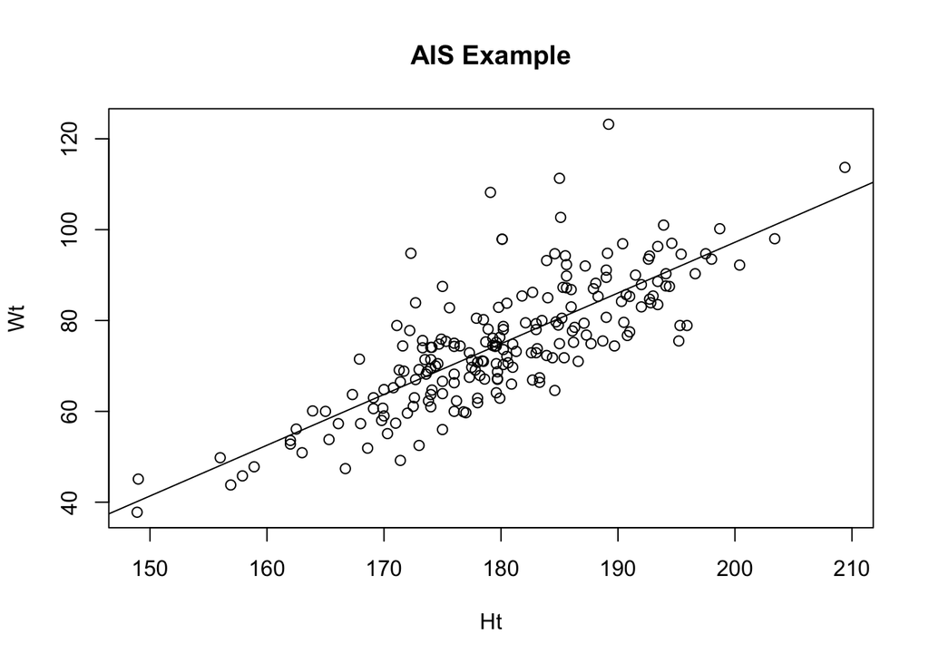

```r
plot(Wt~Ht,main="AIS Example",data=ais)
abline(mod)
```

Note take a look at the abline help file for more detail.

### Properties of OLS

To put it lightly OLS is a big deal. It is the base method for linear regression, and has very important interpreations, which we will discuss shortly. First we need to get a feel for what some of the properties of OLS are, because it may give us a better intuition of what this line actually is. In this part the bullet points actually matter, the details are just for completeness for you.

- $\hat{y_i}$ (the fitted value at $x_i$) produced from a weighted sum of the $Y$’s

Let $c_i=\frac{(x_i-\bar{x})}{SXX}$ then we have that:
$$\hat{\beta}_1=\frac{SXY}{SXX}=\sum\frac{(x_i-\bar{x})}{SXX}y_i=\sum c_iy_i$$

We also have that
$$\hat{\beta}_0=\bar{y}-\hat{\beta}_1\bar{x}=\sum(\frac{1}{n}-c_i\bar{x})y_i=\sum d_iy_i$$

This leaves us with
$$\hat{y_i}=\sum (d_i+c_i)y_i=\sum h_iy_i$$
What this tells us is every predicted value, every point on the line, is a weighted sum of all the observations.

- The fitted value of a general line as $X=\bar{x}$ is $\bar{y}$ for OLS

$$\hat{E}(Y \mid X=\bar{x})=\hat{\beta}_0+\hat{\beta}_1\bar{x}\\
=\bar{y}-\beta_1\bar{x}+\beta_1\bar{x}\\
=\bar{y}$$

- As long as we include an intercept in our model $\sum \hat{\epsilon}_i=0$

- The OLS estimates are unbiased $E(\hat{\beta}_0)=\beta_0$ and $E(\hat{\beta}_1)=\beta_1$

All this means is the estimator we are using us estimating what we think it is theoretically.

- The Gauss Markov Theorem: OLS is the BLUE (Best Linear Unbiased Estimator)

The Gauss Markov Theorem is a very powerful tool. What it says is that the OLS estimates are the best linear unbiased estimators. To quote Sandy Weisberg in his text this means “if one believes in using linear unbiased estimates, the OLS estimates are the one to use.” For the most part in this course linear unbiased estimators are going to be our focus, so OLS is the tool we will use since it is the best. The “best” in this context means smallest variance of the residuals, and linear means linear combinations of the $y$’s.

- We have a Central Limit Theorem that Gives Normality of the Coefficients

This is one of the more interesting and newer properties. For small sample sizes we can make the assumptions that
$$\epsilon_i\sim NID(0,\sigma^2)$$

Where $NID$ means normally identically independently distributed (iid). This gives us normality of our coefficients and will be jointly normal (we will discuss the variances of this in the next section). This is a very stringent assumption and one we don’t need if the sample size is large.

If the sample size is large enough (who knows what that means) we don’t need a distributional assumption on our errors. This is great because it makes our model less restrictive and is one less thing to worry about. The main condition (see your text for the reference) is that the maximum of $\frac{x_i-\bar{x}}{SXX}$ is must get close to zero as the sample increases. For this to be true either the maximum distance between an observation is small or $SXX$ is large, or a combination of the two. Ideally it means the data is either really well grouped or the furthest absolute distance between an observation and the mean is small relative to the overall spread. We can check this directly if needed.

### Variances of Coefficients

Understanding the concepts of variance is really important to all of this, but the major take away from this is that the estimates for the slope and intercept are correlated, if you just look at the equation we use to estimate them you can see they are dependent. What follows is a discussion if the details of this, but in all actuality what you need to understand is that these estimates are correlated, and how to obtain the value of the covariance which is contained at the bottom of this section.

We know since $\hat{\beta}_1$ and $\hat{\beta}_0$ are estimates of parameters that depend on $\epsilon_i$. We also know that $Var(\epsilon_i)=\sigma^2$ for all observations, and we have independence of observations. .

The actual variance of our estimates are:
$$Var(\hat{\beta}_1)=\frac{\sigma^2}{SXX}\\
Var(\hat{\beta}_0)=\sigma^2(\frac{1}{n}+\frac{\bar{x}^2}{SXX})$$

We will use the notation $se( )$ to denote the standard error of the coefficients, so
$$se(\hat{\beta}_1)=\sqrt{\hat{Var}(\hat{\beta}_1)}$$

Note that the standard error is always going to refer to the square root of the estimated variance. THIS IS NOT THE SAME AS STANDARD DEVIATION, which in our terms are reserved for the variability of random variables (observable or not). Rule of thumb, standard error is for estimates, standard deviation is for random variables.

Just to show you a few of the methods in R, the $vcov$ function gives the variance covariance matrix of the coefficients. Normally you don’t look at this directly, but it’s useful to see what is going on in your coefficients.

```r
summary(mod)$sigma^2
```

```
## [1] 76.0437
```

```r
summary(mod)$sigma
```

```
## [1] 8.720304
```

```r
sum(mod$residuals)
```

```
## [1] -2.559064e-14
```

```r
vcov(mod)
```

```
##             (Intercept)           Ht
## (Intercept) 129.8815676 -0.719057556
## Ht           -0.7190576  0.003992458
```

### Confidence Intervals and Testing

We understand that $(\hat{\beta}_0, \hat{\beta}_1)$ are estimates from our current sample, but we don’t want to just understand a single sample. We want to make inference to the population that our sample came from. To do this we need to figure out what values could be relevant, in this case we will foucs on two methods; Confidence Intervals (CI) and T-Tests. This should be just a basic reminder, confidence intervals define a range of values that would be valid for the population statistic. To do this we use a critical value based on a distribution, in our case we will use the t-distribution at the $(1-\alpha)*100\%$ confidence level. In essence every confidence interval follows the form of:
$$Est \pm CV(1-\alpha) * se(Est)$$

The other tool that we will use throughout the semester is the t-test. The t-test itself can tell us if a value is close enough to our estimate. It is useful in the instance where we are trying to replicate results from a previous experiment. Especially in the regression case it tells us if relationships actually exist. Ideally we set a significance level first $\alpha$, then we define a Null and Alternative Hypothesis. The Null hypothesis always has the equal sign in it, we define the opposite (not equal, greater than, less than). We will directly discuss these tests. We define $t(\alpha/2,d)$ to be the $alpha/2$ quantile of the t-distribution with $d$ degree of freedom, defines a value that places $\alpha/2$ in the upper tail of the t-distribution. Note this is tricky and is the same form that your textbook uses.

####Intercept

The $(1-\alpha)*100\%$ CI produce for the intercept is:
$$\hat{\beta}_0 - t(\alpha/2,n-2)*se(\hat{\beta}_0) \leq \hat{\beta}_0 \leq \hat{\beta}_0 + t(\alpha/2,n-2)*se(\hat{\beta}_0)$$

While the t-test requires we define the hypotheses as
$$\mathrm{NH:}\beta_0 =\beta_0^* \, , \beta_1 \mathrm{\,is\,\, arbitrary}\\
\mathrm{AH:} \beta_0 \neq \beta_0^*\, ,\beta_1 \mathrm{\,is\,\, arbitrary}\\$$

Then our test statistic becomes
$$t^*=\frac{\hat{\beta}_0-\beta_0^*}{se(\hat{\beta_0})} \sim t_{n-2}$$
Where $t_{n-2}$ represents a t distribution with $n-2$ degrees of freedom. For the two sided test we reject the null hypothesis when $\mid t^* \mid \geq t(\alpha/2,n-2)$.
The basic R summary of linear models shows the case when $\beta_0^*=0$.

Testing and CI’s on $\hat{\beta_0}$ are rarely used in essence because of the interpretation.

We know the basic interpretation of the intercept comes from it being **the $E(Y \mid X=0)$** but this only applies when we observe data when $X=0$, if this is not the case this interpretation makes no sense. To make this statement we would be extrapolating which means we are commenting on the data outside of the area we have observed. **When the don’t observe data at $X=0$ the only interpretation we have is that $\hat{\beta}_0$ is a tuning parameter**. For our purposes unless otherwise told we will always use an intercept.

####The Slope

The $(1-\alpha)*100\%$ CI produce for the intercept is:
$$\begin{equation}
\hat{\beta}_1 - t(\alpha/2,n-2)*se(\hat{\beta}_1) \leq \hat{\beta}_1 \leq \hat{\beta}_1 + t(\alpha/2,n-2)*se(\hat{\beta}_1)
\end{equation}$$

While the t-test requires we define the hypotheses as
$$\begin{eqnarray*}
\mathrm{NH:}\beta_1 &=&\beta_1^* \, , \beta_0 \mathrm{\,is\,\, arbitrary}\\
\mathrm{AH:} \beta_1 &\neq & \beta_1^*\, ,\beta_0 \mathrm{\,is\,\, arbitrary}\\
\end{eqnarray*}$$

Then our test statistic becomes
$$\begin{equation}
t^*=\frac{\hat{\beta}_1-\beta_1^*}{se(\hat{\beta_1})} \sim t_{n-2}
\end{equation}$$
We then follow the same principles as what we have in $\beta_0$.

For the most part slope coefficients are what we care about specifically whether or not the coefficient in 0. That is we set $\beta_1^*=0$. Think of what the interpretation of this test is, it means does the relationship exist or not. This is also the default test that is produced in R. Overall this is one of the more important tests we have because of the interpretation.

** We interpret $\hat{\beta}_1$ as the “average” increase/decrease in $Y$ when $X$ is moved one unit**. This comes about from the fact that:

$$E(Y \mid X=x+1)-E(Y\mid X=x) = \beta_0+\beta_1(x+1)-\beta_0-\beta_1x \\
= \beta_1x+\beta_1-\beta_1x \\
= \beta_1$$

So the idea here is that we have need to test these coefficients to see what they mean. Typically the only test that matters is does a slope coefficient equal to zero. If we can prove that the slope isn’t equal to zero we can say there is a relationship between the predictors. The test of a coefficient at zero is simple, and even simpler using software, especially R. The test provided by R is the one that the coefficient (estimate) is equal to zero. The first column of the summary output is the coefficient estimates, and the second is the standard error of the estimates. The third and foruth column is what we care about, it give the two sided hypothesis test that the coefficient in the corresonding row is equal to zero or not equal to zero. The test statistics (just estimate divided by standard error) and the corresponding p-value for the test. Based on this output what do you see? I see both have p-values that are very small, way below the .05 threshold that people normally use. So you’d say I reject the null hyptothesis that the coefficient is 0. But do we really care about that with regard to the intercept? Normally the answer to that question is no, but there could be a situation arise, where it is viewed as an offset expected to be zero. What we do care about is the test for the slope, this allows us to say that a relationship exists between height and weight.

Again we know these are just estimates so what can we say about the possible values, again calculate the cofidence interval. To do this in R we just use the confint function. Then the interepretation works just like any other interval. Again we don’t care much about the intercept, but we can say that we are 95% confident that the true slope coefficient is between .992 and 1.24. Theoretically this looks great

```r
summary(mod)
```

```
##
## Call:
## lm(formula = Wt ~ Ht)
##
## Residuals:
##     Min      1Q  Median      3Q     Max
## -16.372  -5.296  -1.197   4.378  38.030
##
## Coefficients:
##               Estimate Std. Error t value Pr(>|t|)
## (Intercept) -126.18901   11.39656  -11.07   <2e-16 ***
## Ht             1.11712    0.06319   17.68   <2e-16 ***
## ---
## Signif. codes:  0 '***' 0.001 '**' 0.01 '*' 0.05 '.' 0.1 ' ' 1
##
## Residual standard error: 8.72 on 200 degrees of freedom
## Multiple R-squared:  0.6098, Adjusted R-squared:  0.6079
## F-statistic: 312.6 on 1 and 200 DF,  p-value: < 2.2e-16
```

```r
confint(mod)
```

```
##                    2.5 %      97.5 %
## (Intercept) -148.6618436 -103.716178
## Ht             0.9925209    1.241713
```

### Prediction and Fitted Values

We have previously discussed inference but what about prediction, or the fitted values of the mean function itself? These are two separate settings

- Prediction: We are predicting a new observation, future value, and was not used in estimating our parameters
- Fitted values are just based on the mean function

Let’s discuss prediction first. For prediction we can easily define $\hat{y_i}$ for the point $x_i$ by just using $\beta_0$ and $\beta_1$. The problem is that is just the mean value of the condtional distribution. A observation $y_*$ is written as
$$y_*=\beta_0+\beta_1x_*+\epsilon_*$$

Let $\tilde{y}_*$ predict the unobserved value for $(y_*,x_*)$. The takeaway here is that even if we estimate the mean function correctly we would still have random error from the $\epsilon$. We need to estimate a variance for this situation it needs to encompass the error from the mean function and the error from prediction ($\epsilon$). Using this idea the variance becomes:
$$Var_{pred}(\tilde{y}_*\mid X=x_*)=\sigma^2+\sigma^2(\frac{1}{n}+\frac{(x_*-\bar{x})^2}{SXX})$$

The standard error becomes
$$sepred(\tilde{y}_*\mid X=x_*)=\hat{\sigma}\left(1+\frac{1}{n}+\frac{(x_*-\bar{x})^2}{SXX}\right)^{\frac{1}{2}}$$
We refer to a prediction interval as:
$$\tilde{y} \pm t(\alpha/2,n-2)*sepred(\tilde{y}_*\mid X=x_*)$$

Think of these as reasonable values that can appear for $y_*$ at $x_*$. This is probably the most asked question we see when it comes to using $\hat{y}$.

For the fitted values we can think think of these as the estimates of the mean at point $x$. Really all we are doing in this case is putting an interval on your mean function. The standard error is calculated by only part of that of $Var_{pred}$.
$$sefit(\hat{y}\mid x_*)=\hat{\sigma}\left(\frac{1}{n}+\frac{(x_*-\bar{x})^2}{SXX}\right)^{\frac{1}{2}}$$

Ideally what we are trying to do is create a set that any possible $(\beta_0,\beta_1)$, which is easily defined the set of all $y$ that fall in between the lines
$$\hat{\beta}_0+\hat{\beta}_1 \pm sefit(\hat{y}\mid x_*)(2F(\alpha,2,n-2))^\frac{1}{2}$$

One thing we will always see is that prediction interval is wider than the confidence interval, Why?

Below we have the example of a prediction interval and confidence interval

```r
predict(mod,newdata=data.frame(Ht=200))
```

```
##        1
## 97.23437
```

```r
predict(mod,newdata=data.frame(Ht=200),interval="prediction",se.fit=TRUE)
```

```
## $fit
##        fit      lwr      upr
## 1 97.23437 79.81899 114.6498
##
## $se.fit
## [1] 1.398885
##
## $df
## [1] 200
##
## $residual.scale
## [1] 8.720304
```

```r
predict(mod,newdata=data.frame(Ht=200),interval="confidence",se.fit=TRUE)
```

```
## $fit
##        fit      lwr      upr
## 1 97.23437 94.47592 99.99283
##
## $se.fit
## [1] 1.398885
##
## $df
## [1] 200
##
## $residual.scale
## [1] 8.720304
```

```r
attach(ais)
```

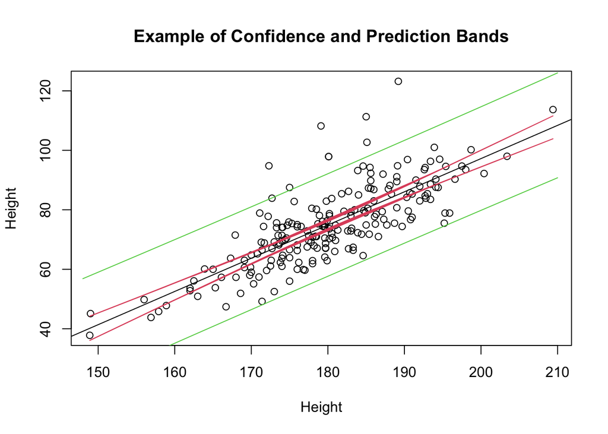

```r
plot(Wt~Ht,xlab="Height",ylab="Height",main="Example of Confidence and Prediction Bands", data=ais)
abline(mod)
CI=predict(mod,interval="confidence")
PI=predict(mod,data.frame(Ht=148:210),interval="prediction")
lines(x=Ht,y=CI[,2],col=2)
lines(x=Ht,y=CI[,3],col=2)
lines(x=148:210,y=PI[,2],col=3)
lines(x=148:210,y=PI[,3],col=3)
```

### R-Squared: $R^2$

We know that if we did not use $X$ in our model the best prediction of any observation would be $\bar{y}$, but since we are conditioning on $X$ we expect to do better. We have said previously part of regression is variance reduction, gaining precision. There are certain values that allow us to to depict this the amount of variance we accounted for by conditioning on $X$. We define the Sum of Squares Regression as
$$SSReg=SYY-RSS$$
We can see it is the difference in the residuals between when we condition on $X$ and when we do not. Since $SSReg$ is on the same scale as $Y$ and the residuals for that matter a large number here may not mean much, the same with a small number. It is relative to the variation of $Y$, so we want to look at this as a percentage of variation accounted for. We define $R^2$, the coefficient of determination as
$$R^2=\frac{SSReg}{SYY}=1-\frac{RSS}{SYY}$$

There are a few different ways to get these values, first is directly from the $R$ output, more indirectly we can get these from the ANOVA table in R which we won’t discuss here. The easiest way is to know that
$$R^2=Cor(Y,X)^2$$

Looking at our AIS data we get that.

```r
attach(ais)
summary(mod)$r.squared
```

```
## [1] 0.6098146
```

```r
cor(Ht,Wt)^2
```

```
## [1] 0.6098146
```

There are other ways to do model validation and comparison that we will discuss in later chapters.

### The Residuals

- When the residuals have curvature/trend with the fitted values
- When there is non-constant variance
- When there are outliers in the residuals
- When the plot is a null plot

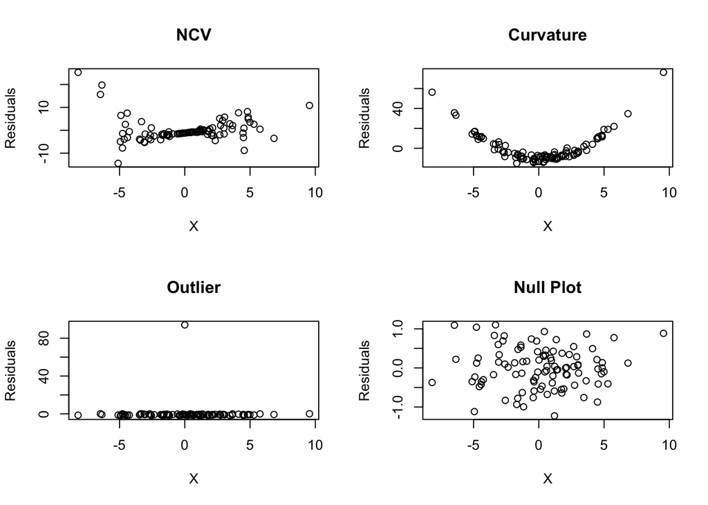

```r
set.seed(128)
X=rnorm(100,0,3)
Y=rep(0,length(X))
for(i in 1:length(X)){
Y[i]=5+3*X[i]+rnorm(1,0,.3*X[i]^2)
}
Y2=5+2*X+X^2+rnorm(100,0,3)
Y3=5+2*X+rnorm(100,0,.5)
Y4=c(Y3,100)
X2=c(X,0)
M2=lm(Y~X)
M3=lm(Y2~X)
M4=lm(Y4~X2)
M5=lm(Y3~X)
par(mfrow=c(2,2))
plot(summary(M2)$residuals~X,ylab="Residuals",xlab="X",main="NCV")
plot(summary(M3)$residuals~X,ylab="Residuals",xlab="X",main="Curvature")
plot(summary(M4)$residuals~X2,ylab="Residuals",xlab="X",main="Outlier")
plot(summary(M5)$residuals~X,ylab="Residuals",xlab="X",main="Null Plot")
```

## Multiple Linear Regression

Multiple linear regression generalized the simple linear regression models by allowing for more than one predictor variable in the mean function.

### Adding a term to SLR

The model we’ve discussed up to this point is
$$E(Y \mid X_1=x_1)=\beta_0+\beta_1x_1.$$

This model works fairly well and has a great interpretation which we have touched on just slightly. But what happens if we think another predictor, $X_2$ will help in describing the conditional mean function of $Y$. What does it mean to add a term to this model? So mathematically we have
$$E(Y \mid X_1=x_1, X_2=x_2)=\beta_0+\beta_1x_1 +\beta_2x_2$$

The main idea in adding another variable, in our case $X_2$ is to explain the part of $Y$ that we couldn’t with only using $X_1$.

### Explaining Variability

Adding terms in essence is about unique information. It is about describing information we haven’t explained in $Y$, but it is also about information that is unique in the predictors. For an example lets say that two uncorrelated variables could explain $100\%$ of the variation in $Y$. This would mean the the variation that is explained jointly is the sum of of the variation they explain individually. This works even if we can’t explain $100 \%$ of the variation in $Y$, the total just becomes the $R^2$ of the model with both variables which is the sum of the $R^2$ of each of the SLR regressions. THIS ONLY WORKS IF THE TWO PREDICTORS ARE INDEPENDENT.

If the two predictors are not independent which is a real world setting the variation of the model with both predictors explain does not add up to the sum explained by the SLR. Again it comes down to unique information since the two predictors are related they share some information, the amount depends on the correlation. With this in mind just looking at the correlation with $Y$ after the first predictor doesn’t work. The question becomes how do we know how much unique information in the new variable $X_2$ that helps explain anything in $Y$.

### Added Variable Plots (AVP)

Added variable plots are a way to see how much information a new variable contains in relationship to a response that has not already been accounted for in a model. Let’s actually write down what we are trying to do. Given a SLR model
$$E(Y \mid X_1=x_1)=\beta_0+\beta_1x_1.$$
We want to see if $X_2$ helps create a better model. We can see how $Y$ relates directly to $X_1$ and $X_2$ through scatterplots, but how can we begin to visualize this. The answer is Added Variable Plots. An added variable plot shows the relationship between the information left over with $X_1$ in the model and the unique information that is in $X_2$ that is not in $X_1$.

To do this we use principles from SLR. We know the information from $Y$ that is not contained in $X_1$ is contained in the residuals of the SLR. The same for the information that is contained in $X_2$ that is not contained in $X_1$. So we need two models
$$M_1 : E(Y \mid X_1=x_1)=\beta_0+\beta_1x_1\\
M_2 : E(X_2 \mid X_1=x_1)=\eta_0+\eta_1x_1$$

Next create a scatter plot where the residuals from $M_1$ are placed on the vertical axis and $M_2$ on the horizontal axis. This relationship will tell us if adding $X_2$ to our model will help at all.

Let’s look at a simulated set up

```r
set.seed(213)
X1=rnorm(100,0,1)
X2=rnorm(100,4,2)
Y=3+2*X1+X2+rnorm(100)
M1=lm(Y~X1)
summary(M1)
```

```
##
## Call:
## lm(formula = Y ~ X1)
##
## Residuals:
##     Min      1Q  Median      3Q     Max
## -5.8233 -1.2994  0.2335  1.7008  5.5713
##
## Coefficients:
##             Estimate Std. Error t value Pr(>|t|)
## (Intercept)   6.9064     0.2410   28.65  < 2e-16 ***
## X1            1.8722     0.2294    8.16 1.15e-12 ***
## ---
## Signif. codes:  0 '***' 0.001 '**' 0.01 '*' 0.05 '.' 0.1 ' ' 1
##
## Residual standard error: 2.408 on 98 degrees of freedom
## Multiple R-squared:  0.4046, Adjusted R-squared:  0.3985
## F-statistic: 66.59 on 1 and 98 DF,  p-value: 1.153e-12
```

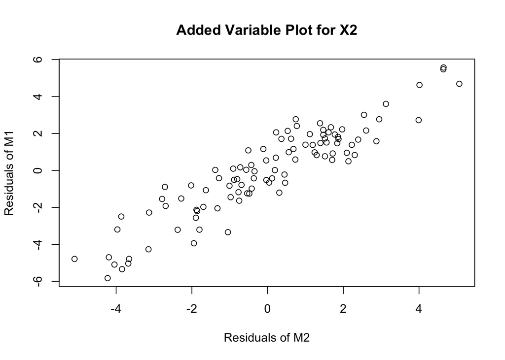

```r
M2=lm(X2~X1)

plot(summary(M1)$residuals~summary(M2)$residuals, xlab="Residuals of M2", ylab="Residuals of M1",main="Added Variable Plot for X2")
```

What if we have a correlation between $X_1$ and $X_2$ the AVP could look like

```r
X3=2+3*X1+rnorm(100,0,4)
Y=3+2*X1+X3+rnorm(100)
M1=lm(Y~X1)
M3=lm(X3~X1)
```

Compare the summary/slope of the added variable plot to the slope associated for X3. It is exactly the same, this says a slope coefficent in MLR accounts for every other variable in the model.

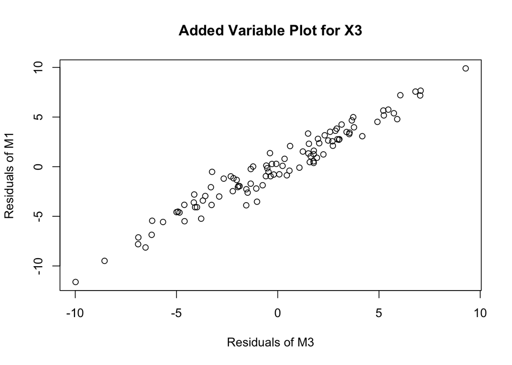

```r
plot(summary(M1)$residuals~summary(M3)$residuals, xlab="Residuals of M3", ylab="Residuals of M1",main="Added Variable Plot for X3")
```

### UN Example

Looking at the data for the UN data set we want to try and describe the mean function of $\log(fertility)$ by $\log(ppgdp)$ and want to see if adding $lifeExpF$ . We will do this through an AVP

```r
library(alr4)
attach(UN11)
head(UN11)
```

```
##                 region  group fertility   ppgdp lifeExpF pctUrban
## Afghanistan       Asia  other     5.968   499.0    49.49       23
## Albania         Europe  other     1.525  3677.2    80.40       53
## Algeria         Africa africa     2.142  4473.0    75.00       67
## Angola          Africa africa     5.135  4321.9    53.17       59
## Anguilla     Caribbean  other     2.000 13750.1    81.10      100
## Argentina   Latin Amer  other     2.172  9162.1    79.89       93
```

```r
Mod1=lm(log(fertility)~lifeExpF+log(ppgdp))
summary(Mod1)
```

```
##
## Call:
## lm(formula = log(fertility) ~ lifeExpF + log(ppgdp))
##
## Residuals:
##      Min       1Q   Median       3Q      Max
## -0.61778 -0.16891  0.03731  0.17591  0.61072
##
## Coefficients:
##             Estimate Std. Error t value Pr(>|t|)
## (Intercept)  3.50736    0.12707  27.601  < 2e-16 ***
## lifeExpF    -0.02824    0.00274 -10.306  < 2e-16 ***
## log(ppgdp)  -0.06544    0.01781  -3.675 0.000307 ***
## ---
## Signif. codes:  0 '***' 0.001 '**' 0.01 '*' 0.05 '.' 0.1 ' ' 1
##
## Residual standard error: 0.248 on 196 degrees of freedom
## Multiple R-squared:  0.6926, Adjusted R-squared:  0.6894
## F-statistic: 220.8 on 2 and 196 DF,  p-value: < 2.2e-16
```

```r
Mod2=lm(log(fertility)~log(ppgdp))
summary(Mod2)
```

```
##
## Call:
## lm(formula = log(fertility) ~ log(ppgdp))
##
## Residuals:
##      Min       1Q   Median       3Q      Max
## -0.79828 -0.21639  0.02669  0.23424  0.95596
##
## Coefficients:
##             Estimate Std. Error t value Pr(>|t|)
## (Intercept)  2.66551    0.12057   22.11   <2e-16 ***
## log(ppgdp)  -0.20715    0.01401  -14.79   <2e-16 ***
## ---
## Signif. codes:  0 '***' 0.001 '**' 0.01 '*' 0.05 '.' 0.1 ' ' 1
##
## Residual standard error: 0.3071 on 197 degrees of freedom
## Multiple R-squared:  0.526,  Adjusted R-squared:  0.5236
## F-statistic: 218.6 on 1 and 197 DF,  p-value: < 2.2e-16
```

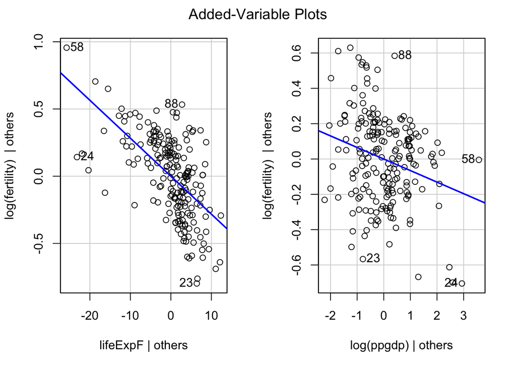

```r
avPlots(Mod1)
```

Notice the estimate from Mod1 for $\log(ppgdp)$ and that in Mod2 do not match up. The reason is because Mod1 is accounting for the information of lifeExpF.

This methodology can generalize to any dimension of model we want, we just always look to see if we add one variable at a time.

### MLR Model

The general MLR model with response $Y$ and predictors $X_1, \ldots, X_p$ take the form
$$E(Y \mid X)=\beta_0+\beta_1X_1+\ldots+\beta_pX_p.$$

Similarly when we condition on specific values of the predictors we get
$$E(Y \mid X)=\beta_0+\beta_1x_1+\ldots+\beta_px_p.$$

When $p$=1 we have a line, and are also in the SLR setting. When $p=2$ we no longer have a line we have 3 dimensional plane. When $p>2$ we have a hyperplane in $(p+1)$ dimensional space, $p$ predictors and the response. This is extremely hard to visualize a general $p$ dimensional space so we will rely on methods like AVP’s to create these model.

### Terms and Predictors

**Transformations of predictors** Sometimes we really would like to use $X_j$ as our predictor but it doesn’t allow for the set up of linear regression. Because we like the ease and interpretation of SLR and MLR we transform the predictors. Look at the UN example just used. This really allows for a lot more flexibility for the problems we can use linear regression for.

**Polynomials and Interactions** Ploynomials represent MLR models where we place $X^d$ where d is as a term/ predictor in our model. This allows for curves to fit our data rather than straight line . As we can see this can be an extremely powerful tool. Interactions allow us to use terms $X_jX_k$ which allow us to model for relationships in predictors that we can exploit. We can also use combinations of variables; weighted averages, rations, $\ldots$, etc. Think of the way BMI uses combinations of height and weight.

**Dummy Variables and Factors** Dummy variables also go by a different name, Indicator variables. That is it is a variable that takes a 1 when the variable is true 0 any other time. So let’s say we want to come up with a variable that says whether or not a treatment was applied or not. When we the treatment is applied the variable takes on a 1 when it is not it is 0. Factors are applied the same way, will discuss how multiple dummy variables allow us to model categorical variables.

**Principal Components** In the real world we have predictors that are related, and in some instances that measure the same thing. What principal components allow us to do is create a special form of a weighted average of these subset of variables.

### Ordinary Least Squares

Making the multiple linear regression we have
$$E(Y \mid X)=\beta_0+\beta_1X_1+\ldots\beta_pX_p\\
Var(Y\mid X)=\sigma^2$$

Where we $\beta$’s and $\sigma^2$ need to be estimated.

### Notation

Just like in SLR we have $n$ observations, but now we are defining that we have p-variate matrix of predictors $X$, and univariate response $Y$. We now define the mean function as
$$E(Y \mid X)=X\beta.$$

Where we define
$$Y=\left(\begin{array}{c}
y_1 \\
\cdots \\
y_n
\end{array} \right)
,\,\,\,
X=\left(\begin{array}{cccc}
1 & x_{11} & \ldots & x_{1p} \\
1 & x_{21} & \ldots & x_{2p} \\
\vdots & \vdots & \vdots & \vdots \\
1 & x_{n1} & \ldots & x_{np}
\end{array} \right)$$

We also define
$$\beta=\left(\begin{array}{c}
\beta_0 \\
\beta_1 \\
\vdots \\
\beta_p
\end{array} \right)$$

So now we can define the MLR problem as
$$Y=X\beta+\epsilon$$
Where $\epsilon$ is defined as
$$\left(\begin{array}{c}
\epsilon_1 \\
\vdots \\
\epsilon_n
\end{array} \right)$$

We can denote the mean function denoted at a point $x_i$ as
$$E(Y\mid X=x_i)=x_i^T\beta=\beta_0+\beta_1x_{i1}+\ldots+\beta_px_{ip}$$

We also make the assumption that
$$E(\epsilon \mid X)=0 , \,\,\, Var(\epsilon \mid X)=\sigma^2I_n$$
where $I_n$ is the identity matrix ( $n \times n$ matrix with diagonal entries of 1). We can also extend this assumption to be $\epsilon\mid X \sim N(0, \sigma^2I_n)$.

### OLS Estimator

Again we choose the estimator $\hat{\beta}$ based on the minimization of the residual sum of squares. So we find
$$\hat{\beta}=\arg \min_\beta RSS(\beta)\\
=\arg \min_\beta \sum_{i=1}^n\, (y_i-x_i^T\beta)^2\\
= \arg \min_\beta \,(Y-X\beta)^T(Y-X\beta)\\
= \arg \min_\beta \, \epsilon^T\epsilon$$

So minimizing the RSS with respect to $\beta$ we get the following
$$\bigtriangledown_\beta RSS(\beta)= -2X^T(Y-X\beta)=0\\
X^TY-X^TX\beta =0\\
X^TX\beta =X^TY\\
\hat{\beta}=(X^TX)^{-1}X^TY$$

When $(X^TX)^{-1}$ exists. To us that means $n>p$ and none of the $X$ variables are too correlated.

The $\beta$ term in software is never computed directly from this equation. They use what is known as a QR decomposition and you can find that in the appendix of your text book. If it is calculated we should calculate it using centered variables. So we define $\tilde{X}$ to be the $X$ matrix with the column means subtracted off, and $\tilde{Y}$ to be the $Y$ vector with the mean subtracted off. The define
$$C=\frac{1}{n-1}\left(\begin{array}{cc}
\tilde{X}^T\tilde{X} & \tilde{X}^T\tilde{Y} \\
\tilde{Y}^T\tilde{X} & \tilde{Y}^T\tilde{Y}\end{array}\right)\\
=\frac{1}{n-1}\left(\begin{array}{cc}
SXX & SXY \\
SXY & SYY
\end{array} \right)$$

Then let $\beta^*$ be the coefficents for $\beta_1, \ldots, \beta_p$ which is
$$\hat{\beta}^*=(\tilde{X}^T\tilde{X})^{-1}\tilde{X}^T\tilde{Y}=(SXX)^{-1}SXY$$
Then $\hat{\beta}_0=\bar{y}-\hat{\beta}^{T*}\bar{x}$ where $\bar{x}$ is the vector of predictor means. Then the fitted values are
$$\hat{Y}=X\hat{\beta}$$

### Properties of the OLS Estimates

Again we have variance estimators for $\hat{\beta}$ and need to come up with an estimator for $\sigma^2$. So we have

$$Var(\hat{\beta})=Var((X^TX)^{-1}X^TY)\\
=(X^TX)^{-1}X^TVar(Y)X(X^TX)^{-1}\\
=\sigma^2(X^TX)^{-1}$$

Then we replace $\sigma^2$ with $\hat{\sigma}^2$, where
$$\hat{\sigma}^2=\frac{RSS}{n-(p+1)}$$

### Coefficient of Determination

Again the Coefficient of Determination is just $R^2$ again. We can break down $SYY$ as
$$SYY=RSS+ SSReg$$

where RSS is the unexplained sum of squares from the model, and the SSReg which is the sum of squares of $Y$ that we can explain by conditioning on $X$. Again we can write $R^2$ as
$$R^2=\frac{SSReg}{SYY}=1-\frac{RSS}{SYY}$$

which is the proportion of variability in $Y$ explained by your model. $R^2$ can also be shown to be
$$R^2=Cor^2(Y,\hat{Y})$$
We also refer to $R^2$ as the multiple correlation coefficient because it is the maximum correlation between $Y$ and any linear combination of the terms in our model. Again this is produced in R anytime we run the summary of a model.

For our example look at the difference between the two models in the UN data the one with and without $lifeExpF$, we can see that the model with it has a 0.69 $R^2$ value while the model without the variable has an $R^2$ of 0.526.

Some people will tell you to always select the model with the highest $R^2$, this isn’t a reasonable thing to do as we can trick a model to always have a higher $R^2$ but may not mean much. We will discuss this much more indepth later, but for now under stand $R^2$ is useful for interpertation purposes of a model, but not for model selection in MLR (ever!).

The MLR setting allows/ requires us to test $\beta_0, \ldots, \beta_p$. For now we will only consider testing the one coefficient at a time. The only change from SLR is the way we write the hypothesis
$$NH: \beta_1 =\beta_1^* \, \,\ ,\ \beta_0,\beta_2,\ldots,\beta_p \, \, \mathrm{is \,\, arbitrary}\\
AH: \beta_1 \neq \beta_1^* \, \,\ ,\ \beta_0,\beta_2,\ldots,\beta_p \, \, \mathrm{is \,\, arbitrary}$$

So we still have the t-test
$$t^*=\frac{\hat{\beta}_j-\beta_j^*}{se(\beta_J)}\sim t_(n-p-1)$$

The alternatives $\beta_j\geq \beta^*$ result in the same test statistic the p-value is the only thing that changes. Remember we only look at the upper or lower tail of the distribution. The default test is R is $\beta^*_j=0$ and results in a two sided p-value with the test statistic degrees of freedom. Again we can look at the summary of model 1 in the UN data.

```r
summary(Mod1)
```

```
##
## Call:
## lm(formula = log(fertility) ~ lifeExpF + log(ppgdp))
##
## Residuals:
##      Min       1Q   Median       3Q      Max
## -0.61778 -0.16891  0.03731  0.17591  0.61072
##
## Coefficients:
##             Estimate Std. Error t value Pr(>|t|)
## (Intercept)  3.50736    0.12707  27.601  < 2e-16 ***
## lifeExpF    -0.02824    0.00274 -10.306  < 2e-16 ***
## log(ppgdp)  -0.06544    0.01781  -3.675 0.000307 ***
## ---
## Signif. codes:  0 '***' 0.001 '**' 0.01 '*' 0.05 '.' 0.1 ' ' 1
##
## Residual standard error: 0.248 on 196 degrees of freedom
## Multiple R-squared:  0.6926, Adjusted R-squared:  0.6894
## F-statistic: 220.8 on 2 and 196 DF,  p-value: < 2.2e-16
```

### Testing and AVP’s

Again we refer to our discussion on AVP’s. We have 3 basic findings when it comes to t-test and AVP’s.

- The slope of the AVP for the term $X_j$ is the same as the slope term for $X_j$ in the full model (See previous example)
- The t-test for the slope in the AVP is similar to that in the full model with the hypothesis that $\beta_j=0$
- The $R^2$ of the AVP for $X_j$ is the partial correlation between the response and $X_j$ adjusted for all the other terms in the model

Again we have the example of AVP’s in the second simulated data set to show the results

```r
summary(lm(summary(M1)$residuals~summary(M3)$residuals))
```

```
##
## Call:
## lm(formula = summary(M1)$residuals ~ summary(M3)$residuals)
##
## Residuals:
##      Min       1Q   Median       3Q      Max
## -2.47763 -0.60187 -0.02853  0.69203  2.81293
##
## Coefficients:
##                         Estimate Std. Error t value Pr(>|t|)
## (Intercept)           -4.552e-16  9.301e-02    0.00        1
## summary(M3)$residuals  1.028e+00  2.478e-02   41.48   <2e-16 ***
## ---
## Signif. codes:  0 '***' 0.001 '**' 0.01 '*' 0.05 '.' 0.1 ' ' 1
##
## Residual standard error: 0.9301 on 98 degrees of freedom
## Multiple R-squared:  0.9461, Adjusted R-squared:  0.9456
## F-statistic:  1721 on 1 and 98 DF,  p-value: < 2.2e-16
```

```r
summary(lm(Y~X1+X3))
```

```
##
## Call:
## lm(formula = Y ~ X1 + X3)
##
## Residuals:
##      Min       1Q   Median       3Q      Max
## -2.47763 -0.60187 -0.02853  0.69203  2.81293
##
## Coefficients:
##             Estimate Std. Error t value Pr(>|t|)
## (Intercept)   2.8608     0.1111   25.76   <2e-16 ***
## X1            1.9313     0.1207   15.99   <2e-16 ***
## X3            1.0278     0.0249   41.27   <2e-16 ***
## ---
## Signif. codes:  0 '***' 0.001 '**' 0.01 '*' 0.05 '.' 0.1 ' ' 1
##
## Residual standard error: 0.9348 on 97 degrees of freedom
## Multiple R-squared:  0.9818, Adjusted R-squared:  0.9815
## F-statistic:  2620 on 2 and 97 DF,  p-value: < 2.2e-16
```

###cPrediction, Fitted Values and Linear Combinations

Again prediction and confidence intervals take on a similar form as in SLR just in matrix notation. For the prediction interval we have that the standard error becomes
$$sepred(\tilde{y}_* \mid x_*)=\hat{\sigma}\sqrt{1+ x^T_*(X^TX)^{-1}x_*}$$

The corresponding standard error for the fitted value is calculated directly as
$$sefit(hat{y} \mid x)=\hat{\sigma}\sqrt{x^T(X^TX)^{-1}x}$$

So we can see that the $sepred$ can be written as
$$sepred(\tilde{y}_* \mid x_*)=\sqrt{\hat{\sigma}^2+ sefit(\tilde{y}_* \mid x_*)^2}$$

Again we look at using the predict function in R, notice for the $ppgdp$ we do not use $\log(ppgdp)$

```r
predict(Mod1,data.frame(lifeExpF=76, ppgdp=14690),interval="confidence")
```

```
##         fit       lwr       upr
## 1 0.7335503 0.6893725 0.7777281
```

```r
predict(Mod1,data.frame(lifeExpF=76, ppgdp=14690),interval="prediction")
```

```
##         fit      lwr      upr
## 1 0.7335503 0.242559 1.224542
```

### The Bootstrap

The bootstrap provides a computationally intense method for getting around using normal assumptions for confidence intervals. The bootstrap also works when standard methods don’t really work for the data set on hand, or methods are questionable.

Bootstrap is based on resampling and computer simulation. For the basic plan of bootstrap for the median look see your text. For the moment we will restrict our discussion to the regression case, in what is known as the case resampling bootstrap. The main idea is to take the sample you have and create $B$ data sets. Then preform regression on the created data sets which will create a distribution of the coefficients of interest. The full procedure is

1. Number the observations from 1 to $n$. Take a random sample WITH REPLACEMENT of size $n$. The probability of the $j$th entry of the new data is equally as likely to be any of the $n$ cases in the original data.
2. Create a dataset based on the sample with replacement. The numbers that appear in the sample are the $n$ observations we use for the new data set.
3. Repeat steps 1 and 2 $B$ times
4. Run our regression model and create an ordering of each coefficent from smallest to largest. Estimate a $95\%$ CI for each coefficient by finding the 2.5 and 97.5 percentiles of the empirical estimates (estimates from the data). We tend to also report the average/median of each of these estimates.

There are a bias correction methods for this. We can set $B$ to be anything we would like but normally it’s $B=999$, for simplicity of calculating the 97.5 and 2.5 percentile. Other methodology also uses large sample theory in the CI’s but use the bootstrap standard errors to calculate them.

The bootstrap is also useful for when large sample theory fails us so when we need to understand the ratio of coefficients we can again use the bootstrap. That is we don’t have a good standard error estimate for $\frac{\beta_j}{\beta_k}$, so the bootstrap bails us out.

Testing with bootstrap is easy, all we ask is does the hypothesized value live in the bootstrap confidence interval.

One of your homework problems for this section will to be calculate and interpert bootstrap confidence intervals for multiple linear regerssion models.

Bootstrap is also useful for predictors that have measurement error. In this case we sample the data with normal (or some distribution) attached to the measurement. We also do the same thing for the predictor variable with another normal random variable. We then fit a line through the origin (OLS with no slope) and then bootstrap on that slope estimate. Overall this is similar to what we discussed earlier in the course with regard to bootstrap, you can also see the literature for more advanced methods of bootstrapping.

## Interpretation and Visualization

The mechanism of fitting linear regression models will stay the same when fitting MLR or SLR models. The one thing that will change in every data set ins the interpretation of your model. Every data set is different, the meanings we try and pull from tests and coefficients change for every new analysis.

### Understand Parameter Estimates

Let’s look at the result of a model a little more complex than what we’ve discussed in class previously

```r
library(alr4)
data(fuel2001)
head(fuel2001)
```

```
##     Drivers    FuelC Income  Miles      MPC      Pop  Tax
## AL  3559897  2382507  23471  94440 12737.00  3451586 18.0
## AK   472211   235400  30064  13628  7639.16   457728  8.0
## AZ  3550367  2428430  25578  55245  9411.55  3907526 18.0
## AR  1961883  1358174  22257  98132 11268.40  2072622 21.7
## CA 21623793 14691753  32275 168771  8923.89 25599275 18.0
## CO  3287922  2048664  32949  85854  9722.73  3322455 22.0
```

```r
fuel2001 <- transform(fuel2001,
     Dlic=1000 * Drivers/Pop,
     Fuel=1000 * FuelC/Pop,
     Income=Income/1000)
head(fuel2001)
```

```
##     Drivers    FuelC Income  Miles      MPC      Pop  Tax      Dlic     Fuel
## AL  3559897  2382507 23.471  94440 12737.00  3451586 18.0 1031.3801 690.2644
## AK   472211   235400 30.064  13628  7639.16   457728  8.0 1031.6411 514.2792
## AZ  3550367  2428430 25.578  55245  9411.55  3907526 18.0  908.5972 621.4751
## AR  1961883  1358174 22.257  98132 11268.40  2072622 21.7  946.5706 655.2927
## CA 21623793 14691753 32.275 168771  8923.89 25599275 18.0  844.7033 573.9129
## CO  3287922  2048664 32.949  85854  9722.73  3322455 22.0  989.6062 616.6115
```

```r
FuelMod<-lm(Fuel~Tax+Dlic+Income+log(Miles), data=fuel2001)
summary(FuelMod)
```

```
##
## Call:
## lm(formula = Fuel ~ Tax + Dlic + Income + log(Miles), data = fuel2001)
##
## Residuals:
##      Min       1Q   Median       3Q      Max
## -163.145  -33.039    5.895   31.989  183.499
##
## Coefficients:
##             Estimate Std. Error t value Pr(>|t|)
## (Intercept) 154.1928   194.9062   0.791 0.432938
## Tax          -4.2280     2.0301  -2.083 0.042873 *
## Dlic          0.4719     0.1285   3.672 0.000626 ***
## Income       -6.1353     2.1936  -2.797 0.007508 **
## log(Miles)   26.7552     9.3374   2.865 0.006259 **
## ---
## Signif. codes:  0 '***' 0.001 '**' 0.01 '*' 0.05 '.' 0.1 ' ' 1
##
## Residual standard error: 64.89 on 46 degrees of freedom
## Multiple R-squared:  0.5105, Adjusted R-squared:  0.4679
## F-statistic: 11.99 on 4 and 46 DF,  p-value: 9.331e-07
```

The right hand side of the equation is interpreted in terms of the response. So in terms of the fuel problem everything is interpreted in gallons. Again we “could” interpret the intercept as the gallons used in a state with no tax, no drives, no income and no roads. Think that exists? Our interpretation would make no sense so we again think of it as a tuning parameter. The other coefficients must be interpreted in gallons but we also need notice what the predictor variable the coefficient is associated with means. For instance the coefficient for $Tax$ is interpreted in gallons per cent of tax. Since $Tax$ is in cents.

### Rate of Change

We’ve talked about interpreting the $\beta_j$ coefficient as the “average increase (decrease) of $Y$ (in the units of $Y$) given that $X_j$ is increased one unit. Fuel in this case is in per person. So the coefficient with $Tax$ is interpreted as ;” We expect to see on average a 4.23 gallon per person decrease given that the tax rate is increased one cent and all other factors are held constant." In SLR it’s easy to visualize what the effect of the variable is. In MLR especially when $p>2$ it is a little harder, what we can do is fix all of the other variables we are not interested in, and then look at a plot of the variable of interest against the response.

We can see that once we fix all the other variables but $Tax$ we have an equation the form of SLR. So we can plot the line and give a $95\%$ CI for the pointwise estimates of $Tax$, given the mean of all the other variables. We can plot this using the following command which results in Figure 1

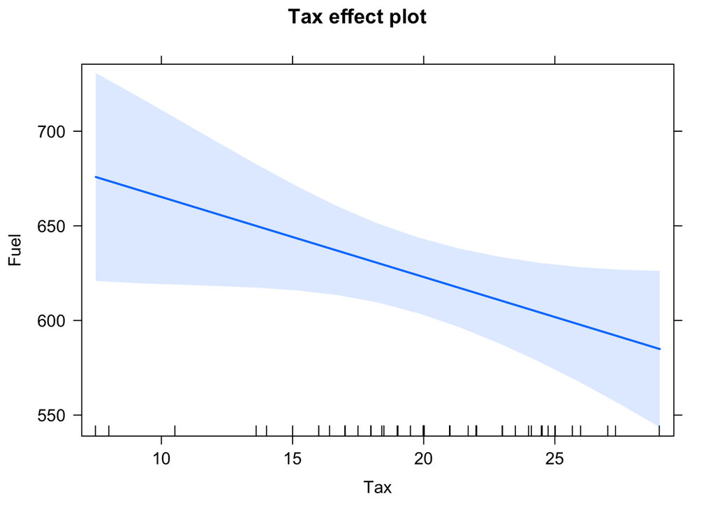

```r
plot(Effect("Tax",FuelMod))
```

Based on the effect plot above can we say that higher tax rate causes lower fuel consumption? No! We observe that states with higher tax rates have lower fuel consumption, so we can say there is an association, but we can’t infer causation. To be able to discuss causation we need to in fact increase or decrease the tax rate and observe the result. Causation is EXTREMELY difficult to get from observational data. We’ll talk more about this later.

### Signs of Estimates

The sign of the estimate of $\beta_j$ gives us the direction of the relationship between $X_j$ and $Y$. If all the terms are independent of one another, the sign of $\beta_j$ is the sign of the correlation. If there is some correlation between predictors signs can change based on what other terms are in the model. This makes interpretation difficult. Imagine having to explain a negative coefficient on a variable that is known to have a positive correlation with the response. This is one of the reasons that in the instance of correlated variables we need to find something else to do. Also we know that if two variables are correlated it is hard for the interpretation of fixing all other variables to make sense. In other words correlated variables are harder to deal with than just putting them in the model.

### Interpretation with Changing Terms

For this section lets look at an example from Sandy Weisberg’s regression text book. We define 2 new variables D9 and D18 which are the weight differences at age 9 and 18 for the girls in the Berkley Guidance Study (the BGSgirls data in the alr4 package). In this case we will fit 3 models.

1. Model 1 has all 3 weight variables
2. Model 2 has $WT2$ $DW9$ and $DW18$
3. Model 3 uses all weight variables, $DW9$, $DW18$.

Let’s compare the estimates for each of the models so we have

```r
library(alr4)
attach(BGSgirls)
names(BGSgirls)
```

```
##  [1] "WT2"   "HT2"   "WT9"   "HT9"   "LG9"   "ST9"   "WT18"  "HT18"  "LG18"
## [10] "ST18"  "BMI18" "Soma"
```

```r
## Difference of weight between age 9 and 2
DW9=WT9-WT2
## Difference of Weight between age 18 and 9
DW18=WT18-WT9

m1=lm(BMI18~WT2+WT9+WT18, data=BGSgirls)
m2=lm(BMI18~WT2+DW9+DW18,data=BGSgirls)
m3=lm(BMI18~WT2+WT9+WT18+DW9+DW18,data=BGSgirls)

compareCoefs(m1,m2,m3)
```

```
## Calls:
## 1: lm(formula = BMI18 ~ WT2 + WT9 + WT18, data = BGSgirls)
## 2: lm(formula = BMI18 ~ WT2 + DW9 + DW18, data = BGSgirls)
## 3: lm(formula = BMI18 ~ WT2 + WT9 + WT18 + DW9 + DW18, data = BGSgirls)
##
##             Model 1 Model 2 Model 3
## (Intercept)    8.31    8.31    8.31
## SE             1.66    1.66    1.66
##
## WT2         -0.3866 -0.0678 -0.3866
## SE           0.1515  0.1275  0.1515
##
## WT9          0.0314          0.0314
## SE           0.0494          0.0494
##
## WT18          0.287           0.287
## SE            0.026           0.026
##
## DW9                  0.3189 aliased
## SE                   0.0386
##
## DW18                  0.287 aliased
## SE                    0.026
##
```

The first thing we see is that the estimate for $WT2$ in model 2 is different than that of the other 2 models. Is there any intution why? It is due to the fact that $DW9$ includes information about from $WT2$. Also notice the fact that $WT18$ in model 1 and model 3 and $DW18$ in model 2 share coefficients. This is the fact that the only $DW18$ can increase 1 KG with all other variables fixed is to increase $WT18$ by one unit. The moral of the story is using the same information in different ways can result in different coefficients, which results in different inference. Also note that $R^2$ and $\sigma^2$ are the same for all 3 models.

### Over-Parameterized Mean Functions

The last thing we should notice is model 3 when inputted into R had 6 coefficients, but the resulting output has 4. Why is the major question? The answer is because we have a rank deficient or over-parameterized model. The idea is we have a variable(s) that is a linear combination of variables that are already in the model, this is called linear dependence. So what we don’t want is given $X_1$ and $X_2$ are already in our model is some $X_3=aX_1+bX_2$ where a and b are constants. What this means is since we know the coefficients for $X_1$ and $X_2$ there is no need to estimate one for $X_3$ and no information we need. Note that this is completely different than using unimportant variables in a model. This says nothing about the test what it says is that no estimate can be calculated for $X_3$.

With this in mind model 3 is over-parameterized in two ways. $DW18=WT18-WT9$ and $DW9=WT9-WT2$, where all 3 weight variables are already in the model. This means that we can’t estimate coefficients for $DW18$ or $DW9$. We will discuss this more in Chapter 5 when we discuss factors in Regression. As for the R code when an over-parameterized model appears we see an $NA$, the following is the output for Model 3

```r
summary(m3)
```

```
##
## Call:
## lm(formula = BMI18 ~ WT2 + WT9 + WT18 + DW9 + DW18, data = BGSgirls)
##
## Residuals:
##     Min      1Q  Median      3Q     Max
## -3.1037 -0.7432 -0.1240  0.8320  4.3485
##
## Coefficients: (2 not defined because of singularities)
##             Estimate Std. Error t value Pr(>|t|)
## (Intercept)  8.30978    1.65517   5.020 4.16e-06 ***
## WT2         -0.38663    0.15145  -2.553    0.013 *
## WT9          0.03141    0.04937   0.636    0.527
## WT18         0.28745    0.02603  11.044  < 2e-16 ***
## DW9               NA         NA      NA       NA
## DW18              NA         NA      NA       NA
## ---
## Signif. codes:  0 '***' 0.001 '**' 0.01 '*' 0.05 '.' 0.1 ' ' 1
##
## Residual standard error: 1.333 on 66 degrees of freedom
## Multiple R-squared:  0.7772, Adjusted R-squared:  0.767
## F-statistic: 76.73 on 3 and 66 DF,  p-value: < 2.2e-16
```

Notice the $NA$’s associated with $DW9$ and $DW18$, again we will return to this in chapter 5.

### Log Transformations

The fuel data uses a log transformation of the variable miles to create the linear model. Log transformation are useful when the variables take on a large range of values, typically when the ratio of the max to min is around 100. It also needs some interpretation work, taking the natural log of a variable isn’t intuitive to most people. To increase log(miles) one unit, miles basically has to double. Sometimes this is the reason we use log base 2 instead of the natural log. But the easiest interpetation for the model is to saw when miles double. We can also show an effect plot as we did for $Tax$. See Figure 2 for this example. Since $\log(Miles)$ is tough to interpret showing this plot could help dramatically, since the sale is in miles.

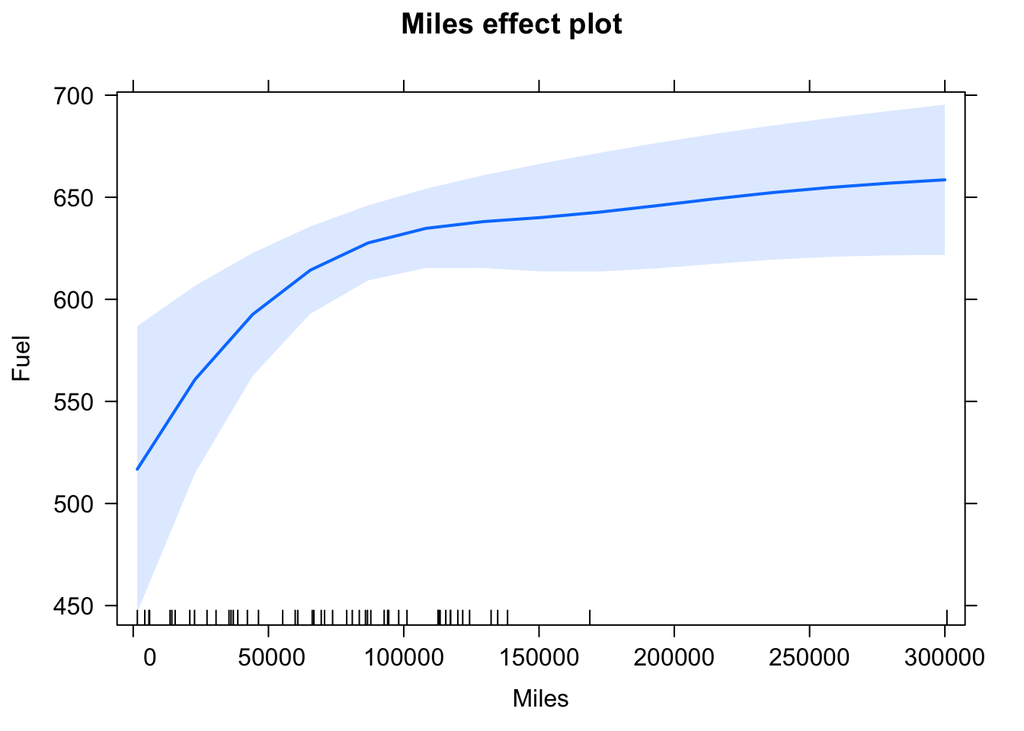

```r
plot(Effect("Miles",FuelMod))
```

We can also have problems when the predictor is transformed. Think back to our UN example for chapter 3. For instance the interpretation of a model where we use $\log(Y)$ is the response since when we interpret coefficients all other coefficients are fixed we will just use the SLR setting. Let our equation be
$$E(\log(Y) \mid X)=\beta_0+\beta_1X\\
E(Y \mid X)=e^{\beta_0+\beta_1X}\\$$

When we look at what happens when we make $X=x+1$ we have
$$E(\log(Y) \mid X=x+1)=\beta_0+\beta_1(x+1)\\
E(Y \mid X)=e^{\beta_0+\beta_1(x+1)}\\
=e^{\beta_0+\beta_1x+\beta_1)}\\
=e^{\beta_1}e^{\beta_0+\beta_1X}\\
=e^{\beta_1}E(Y \mid X)$$

This also has an interpretation as the rate of change, see your text for the full calculation, but the idea is that the percent increase/decrease of $Y$ when $X_j$ is increased by 1 unit is equivalent to
$$100(e^{\beta_1}-1)$$

To see more examples of these cases lets look back at the UN data example when both $\log(ppgdp)$ and $lifeExpF$ are in the model.

```r
ModUN=lm(log(fertility)~log(ppgdp)+lifeExpF,data=UN11)
summary(ModUN)
```

```
##
## Call:
## lm(formula = log(fertility) ~ log(ppgdp) + lifeExpF, data = UN11)
##
## Residuals:
##      Min       1Q   Median       3Q      Max
## -0.61778 -0.16891  0.03731  0.17591  0.61072
##
## Coefficients:
##             Estimate Std. Error t value Pr(>|t|)
## (Intercept)  3.50736    0.12707  27.601  < 2e-16 ***
## log(ppgdp)  -0.06544    0.01781  -3.675 0.000307 ***
## lifeExpF    -0.02824    0.00274 -10.306  < 2e-16 ***
## ---
## Signif. codes:  0 '***' 0.001 '**' 0.01 '*' 0.05 '.' 0.1 ' ' 1
##
## Residual standard error: 0.248 on 196 degrees of freedom
## Multiple R-squared:  0.6926, Adjusted R-squared:  0.6894
## F-statistic: 220.8 on 2 and 196 DF,  p-value: < 2.2e-16
```

How do we interpret this model? Take a shot at interepreting both variables.

### Experimentation vs Observation

Up to this point we have briefly discussed the fact that the data we have used does not lend its self to causal inference. This means we can say that $X$ and $Y$ have an association with $\beta_j$ being the coefficient. To gain causation, we need to use experimental data not causal data. Up to this point we have thought of $X_j$ as being a random variable, but what if it is not random at all. What if an experimenter sets what $X_j$ can be, meaning $X_j$ is no longer a random variable and then observes $Y$. This lends itself to inferring causality, because we can control all other variables that can effect our outcome, and can only change $X_j$. We can say then $X_j$ produces some result in $Y$.

This assumption seems ridiculous in an observational study because in reality the analyst/scientist has no control over any of the variables. There has been alot of study on how to use observational data in causality, but it requires additional assumptions on future predictions of the data and very specific cases. See your text for a reference on this material.

One major issue we have with inferring causality is that we miss the major variable that is causing the effect on $Y$. We know adding a variable will change our inference dramatically, just think about the implications if it is important to the mean function. This is what we refer to as a lurking variable. When we leave lurking variables out we bias our model, the model is incorrect, therefore the inference we make in a causal form won’t be correct.

### Comments on $R^2$

$R^2$ is probably one of the most cited but most misunderstood values in regression. The main thing it always is, is the percent of variability in $Y$ that we have explained using the model, based on the sample. This value can be deceiving because what if your model is wrong, what if a quadratic term is needed or you need a log transformation on the response or $X$. If the data is from a multivariate normal it is also dependent on the sampling plan, if your sampling is taken over too small of a region of $X$ it is likely that your $R^2$ will be small because the variation of $Y$ will not be large, and if you sample over to large of a range of $X$ any $Y$ has high variability, your $R^2$ will be inflated just due to the variability of $Y$.

####$R^2$ in SLR

$R^2$ in SLR is useful because we have a diagnostic to see if your model is wrong. We can plot our data with the SLR line through it, and see if the model fits the data. We can also compare it to a smoother. If we remember $R_{XY}^2=\Cor^2(X,Y)$ then $R^2$ only means something when correlation is the correct measure of the relationship, specifically when the relationship is a straight line. If the line isn’t straight or the model is wrong $R^2$ doesn’t mean anything.

####$R^2$ in MLR

$R^2$ is the squared correlation between $Y$ and the fitted values $\hat{Y}$. This means that plotting the fitted values of $Y$ against $\hat{Y}$, if it looks like this plot comes from a normal population, then $R^2$ is representative of the population. If it is not it depends on the sampling plan again. $R^2$ applies to other regression methods such as non-linear regression as well. This does not extend to all regression methods though, like binary regression/ logistic regression.

It also does not apply to regression through the origin (without an intercept). $R^2$ for MLR with a intercept is what is called invariant, meaning that if we change the scale of the response , say from Celsius to Fahrenheit (scaled) the $R^2$ won’t change. If we change the intercept this is no longer true, so we shouldn’t use $R^2$ for regression without an intercept.